# Compare_Several_Types_Of_Volcano_Plots

Mohammad Reza Mohajeri

2023-09-16

#### ================================================================================================

## Volcano Plot Scripts for RNA-Seq Analysis Visualization in R

#### ================================================================================================

####- This Rmd file provides a collection of scripts to generate volcano plots for visualizing RNA-Seq analysis results. #### - Here, we employ three distinct methods for creating these plots to offer various perspectives and customizability.

#### ================================================================================================

#### 1. ggplot2 Volcano Plot (Method 1): Leveraging the powerful ggplot2 package, this section offers a detailed and customizable volcano plot.

#### 2. ggplot2 Volcano Plot (Method 2): An alternative rendition using ggplot2, providing a different visualization approach.

#### 3. EnhancedVolcano Plot (Method 3): Making use of the EnhancedVolcano package in R, this section is tailored for generating informative volcano plots in a genomics context.

#### ================================================================================================

#### ================================================================================================

## CUSTOM GGPLOT2 VOLCANO PLOT (METHOD 1)

#### Visualization is enhanced using a custom color palette.

#### The generated plot is saved as a PDF for future reference.

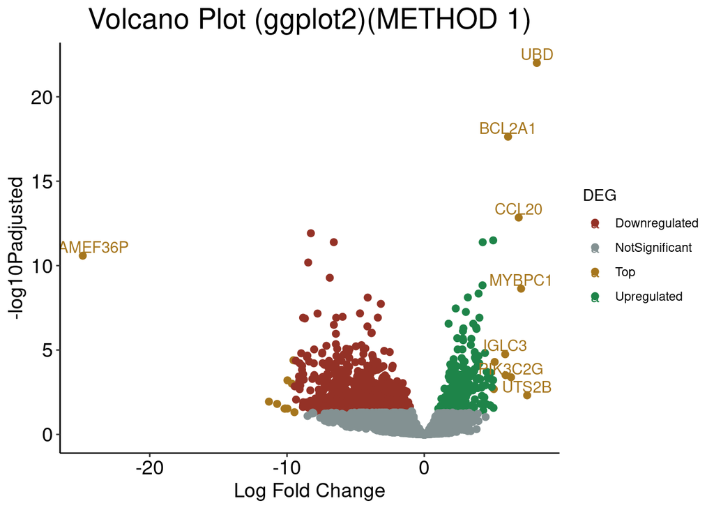

```r
# ----------------------------------------------------------
# Section 1: Define the volcano_plot Function
# ----------------------------------------------------------
volcano_plot <- function(padjlevel,
                         Up_FC,
                         Down_FC,
                         ntop) {

# ----------------------------------------------------------
# Section 2: Create Output Directory for Plots
# ----------------------------------------------------------
  dir.create("plots", showWarnings = FALSE)

# ----------------------------------------------------------
# Section 3: Read the Data
# ----------------------------------------------------------
  volcano <- data.frame(read_csv(paste0("DESeq2/DESeq2_Unsorted_All_Genes.csv")))

# ----------------------------------------------------------
# Section 4: Preprocess the Data
# ----------------------------------------------------------
  colnames(volcano)
  volcano <- volcano %>%
    mutate( neg_log10padj = -log10(padj)) %>%
    mutate(DEG = "NotSignificant" ) %>%
    mutate(DEG = ifelse( neg_log10padj > -log10(padjlevel) & log2FoldChange > Up_FC, "Upregulated", DEG)) %>%
    mutate(DEG = ifelse( neg_log10padj > -log10(padjlevel) & log2FoldChange < Down_FC, "Downregulated", DEG))

# ----------------------------------------------------------
# Section 5: Define Color Palette
# ----------------------------------------------------------
my_pal <- c("#943126", "#839192", "#A6761D", "#1E8449")

# ----------------------------------------------------------
# Section 6: Create Data Subsets
# ----------------------------------------------------------
  volcano_up <- volcano[which(volcano$DEG == "Upregulated"),]
  volcano_up <- volcano_up[order(volcano_up$log2FoldChange, decreasing = TRUE), ]

  volcano_down <- volcano[which(volcano$DEG == "Downregulated"),]
  volcano_down <- volcano_down[order(volcano_down$log2FoldChange, decreasing = F), ]

  volcano_NotSignificant <- volcano[which(volcano$DEG == "NotSignificant" ),]

  volcano_all <- rbind(volcano_up, volcano_down, volcano_NotSignificant)

# ----------------------------------------------------------
# Section 7: Modify Data Frame for Plotting
# ----------------------------------------------------------
  colnames(volcano_all)

  ntop_rep <- rep("Top", ntop)
  volcano_all$DEG <- c(ntop_rep, volcano_up$DEG[-c(1:ntop)],
                       ntop_rep, volcano_down$DEG[-c(1:ntop)],
                       volcano_NotSignificant$DEG)

  volcano_all$Top <- ifelse(volcano_all$DEG == "Top",
                            volcano_all$Symbol, "")

# ----------------------------------------------------------
# Section 8: Create the Volcano Plot
# ----------------------------------------------------------
  g <- ggplot(data = volcano_all,
          aes(x = log2FoldChange, y =  neg_log10padj, color = DEG, fill = DEG, label = Top)) +


      geom_point(size = 2, shape = 21) +
      geom_text(check_overlap = T, vjust = -0.1, nudge_y = 0.1) +
      scale_color_manual(values = my_pal) +
      scale_fill_manual(values = my_pal) +

      theme_classic() +
      labs(x = "Log Fold Change", y = "-log10Padjusted", title = "Volcano PLot")


# ----------------------------------------------------------
# Section 9: Customize the Plot and Save
# ----------------------------------------------------------
  g <- g + theme(axis.line = element_line(linetype = "solid"),
                 axis.title = element_text(size = 14),
                 axis.text = element_text(size = 14, colour = "black"),
                 plot.title = element_text(size = 20, hjust = 0.5)) +
      labs(title = "Volcano Plot (ggplot2)(METHOD 1)")

  pdf("plots/volcanoplot.pdf", width = 10, height = 8)
  print(g)
  dev.off()

# ----------------------------------------------------------
# Section 10: Return the Plot
# ----------------------------------------------------------
  return(g)

}

# ----------------------------------------------------------
# Section 11: Call the volcano_plot Function
# ----------------------------------------------------------
volcano_plot(padjlevel = 0.05,
             Up_FC = 1,
             Down_FC = -1,
             ntop = 10)
```

#### ================================================================================================

## OPTIMIZED GGPLOT2 VOLCANO PLOT (METHOD 2)

#### ================================================================================================

#### This is an advanced rendition using ggplot2 focusing on visual clarity.

#### Key features include:

#### - Identification and individual labeling of the top 5 upregulated and downregulated genes along with their fold change.

#### - Styling the plot with a minimalistic theme.

#### - Customized axes and titles for better clarity.

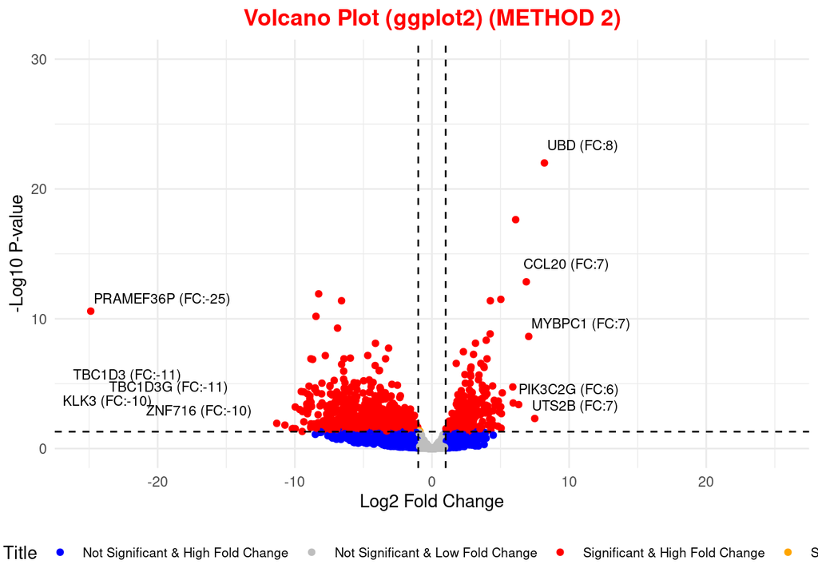

```r
# ----------------------------------------------------------
# Section 1: Load Required Packages
# ----------------------------------------------------------
# Load ggplot2 for plotting and dplyr for data manipulation
library(ggplot2)
library(dplyr)

# ----------------------------------------------------------
# Section 2: Read and Preprocess Data
# ----------------------------------------------------------
# Read the CSV file into a data frame
data <- read.csv("DESeq2/DESeq2_Unsorted_All_Genes.csv")

# ----------------------------------------------------------
# Section 3: Identify Top Genes
# ----------------------------------------------------------
# Filter the top 5 upregulated genes based on adjusted p-value and log2FoldChange
top_5_up <- data %>%
  filter(padj <= 0.05) %>%
  arrange(desc(log2FoldChange)) %>%
  head(5)

# Filter the top 5 downregulated genes based on adjusted p-value and log2FoldChange
top_5_down <- data %>%
  filter(padj <= 0.05) %>%
  arrange(log2FoldChange) %>%
  head(5)

# ----------------------------------------------------------
# Section 4: Create Separate Data Subsets for Top 5 Genes
# ----------------------------------------------------------
# Create separate data subsets for each of the Top 5 genes
up_1 <- top_5_up[1, ]
up_2 <- top_5_up[2, ]
up_3 <- top_5_up[3, ]
up_4 <- top_5_up[4, ]
up_5 <- top_5_up[5, ]

down_1 <- top_5_down[1, ]
down_2 <- top_5_down[2, ]
down_3 <- top_5_down[3, ]
down_4 <- top_5_down[4, ]
down_5 <- top_5_down[5, ]

# ----------------------------------------------------------
# Section 5: Create Volcano Plot with ggplot2
# ----------------------------------------------------------
# Create Volcano Plot with ggplot2
ggplot(data, aes(x=log2FoldChange, y=-log10(padj))) +
  # Add points based on significance and fold change
  geom_point(aes(color =
                    case_when(
                      padj > 0.05 & abs(log2FoldChange) < 1  ~ "Not Significant & Low Fold Change",
                      padj > 0.05 & abs(log2FoldChange) > 1  ~ "Not Significant & High Fold Change",
                      padj <= 0.05 & abs(log2FoldChange) < 1 ~ "Significant & Low Fold Change",
                      padj <= 0.05 & abs(log2FoldChange) > 1 ~ "Significant & High Fold Change"
                    )
                 ), alpha = 1) +

  # Add labels for top 5 upregulated genes
  geom_text(data = up_1, aes(label = sprintf("%s (FC:%d)", Symbol, round(log2FoldChange))),
            vjust = -1, hjust = 0, nudge_x = 0.2, nudge_y = 0.2, size = 3) +
  geom_text(data = up_2, aes(label = sprintf("%s (FC:%d)", Symbol, round(log2FoldChange))),
            vjust = -1, hjust = 0, nudge_x = -0.2, nudge_y = -0.2, size = 3) +
  geom_text(data = up_3, aes(label = sprintf("%s (FC:%d)", Symbol, round(log2FoldChange))),
            vjust = -1, hjust = 0, nudge_x = 0.2, nudge_y = -0.2, size = 3) +
  geom_text(data = up_4, aes(label = sprintf("%s (FC:%d)", Symbol, round(log2FoldChange))),
            vjust = -1, hjust = 0, nudge_x = -0.2, nudge_y = 0.2, size = 3) +
  geom_text(data = up_5, aes(label = sprintf("%s (FC:%d)", Symbol, round(log2FoldChange))),
            vjust = -1, hjust = 0, nudge_x = 0, nudge_y = 0, size = 3) +


   # Add labels for top 5 downregulated genes
  geom_text(data = down_1, aes(label = sprintf("%s (FC:%d)", Symbol, round(log2FoldChange))),
            vjust = -1, hjust = 0, nudge_x = 0.2, nudge_y = -0.2, size = 3) + # PRAMEF36P
  geom_text(data = down_2, aes(label = sprintf("%s (FC:%d)", Symbol, round(log2FoldChange))),
            vjust = -4, hjust = 1.5, nudge_x = -3, nudge_y = 0.2, size = 3) + # TBC1D3
  geom_text(data = down_3, aes(label = sprintf("%s (FC:%d)", Symbol, round(log2FoldChange))),
            vjust = -3, hjust = 1.5, nudge_x = 0.2, nudge_y = 0.2, size = 3) + # TBC1D3G
  geom_text(data = down_4, aes(label = sprintf("%s (FC:%d)", Symbol, round(log2FoldChange))),
            vjust = -2, hjust = 2.6, nudge_x = 0.2, nudge_y = 0.2, size = 3) + # KLK3
  geom_text(data = down_5, aes(label = sprintf("%s (FC:%d)", Symbol, round(log2FoldChange))),
            vjust = -1, hjust = 1, nudge_x = -3, nudge_y = 0.2, size = 3) + # ZNF716

   # Custom scale, theme, and labels
  scale_shape_manual(values = c("Top 5 Genes" = 3)) +
  scale_color_manual(values = c("Not Significant & Low Fold Change" = "grey",
                                "Not Significant & High Fold Change" = "blue",
                                "Significant & Low Fold Change" = "orange",
                                "Significant & High Fold Change" = "red")) +
  xlim(c(-25, 25)) +
  ylim(c(0, 30)) +
  geom_hline(yintercept = -log10(0.05), linetype = "dashed", color = "black") +
  geom_vline(xintercept = c(-1, 1), linetype = "dashed", color = "black") +
  theme_minimal() +
  labs(
    title = "Volcano Plot (ggplot2) (METHOD 2)",
    x = "Log2 Fold Change",
    y = "-Log10 P-value",
    color = "Custom Legend Title",
    shape = "Special Points"
  ) +

  theme(
    legend.position = "bottom",
    legend.text = element_text(size = 8),
    plot.title = element_text(
        size = 14,      # Adjusts font size
        color = "red",   # Adjusts font color
        face = "bold",   # Adjusts font face ("plain", "bold", "italic", "bold.italic")
        hjust = 0.5,     # Horizontal adjustment (0 is left, 0.5 is center, 1 is right)
        vjust = 1        # Vertical adjustment (0 is bottom, 1 is top)
    )
)
```

#### ———————————————————————————————–

## 3- Enhanced Volcano Plot Generation

#### ———————————————————————————————–

#### Purpose:

#### This code chunk is responsible for generating the Enhanced Volcano plot.

#### The plot visualizes the differentially expressed genes based on their log2FoldChange and

#### adjusted p-values (padj).

#### Key Features:

#### - Custom coloring schemes based on significance and fold change.

#### - Highlights and labels the top 5 upregulated and downregulated genes.

#### - Axes and labels are appropriately scaled and styled.

#### - Y-axis is transformed using -log10 for better visual discrimination of smaller p-values.

#### The plot is fine-tuned to be publication-ready, incorporating best practices in data visualization.

#### ———————————————————————————————–

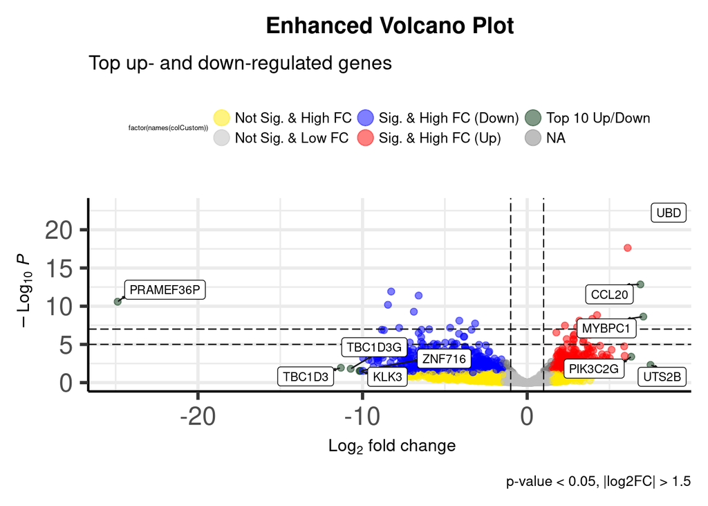

```r
# ----------------------------------------------------------
# Load Required Packages
# ----------------------------------------------------------
library(EnhancedVolcano)
library(dplyr)

# ----------------------------------------------------------
# Read and Preprocess Data
# ----------------------------------------------------------
res <- read.csv("DESeq2/DESeq2_Unsorted_All_Genes.csv")

# ----------------------------------------------------------
# Identify Top 5 Upregulated and Downregulated Genes
# ----------------------------------------------------------
top_5_up_EnhancedVolcano <- res %>%
  filter(padj <= 0.05) %>%
  arrange(desc(log2FoldChange)) %>%
  head(5)

top_5_down_EnhancedVolcano <- res %>%
  filter(padj <= 0.05) %>%
  arrange(log2FoldChange) %>%
  head(5)

# ----------------------------------------------------------
# Create Keyvals for Custom Colors
# ----------------------------------------------------------
# Create Keyvals for Custom Colors
keyvals <- case_when(
    res$padj > 0.05 & abs(res$log2FoldChange) < 1.5  ~ 'gray',
    res$padj > 0.05 & abs(res$log2FoldChange) >= 1.5 ~ '#ffea00',
    res$padj <= 0.05 & res$log2FoldChange > 1.5      ~ '#FF0000',
    res$padj <= 0.05 & res$log2FoldChange < -1.5     ~ '#0000FF',
    TRUE                                            ~ 'default'
)


# Assign Names to the Keyvals for the Legend
names(keyvals)[keyvals == 'gray'] <- 'Not Sig. & Low FC'
names(keyvals)[keyvals == '#ffea00'] <- 'Not Sig. & High FC'
names(keyvals)[keyvals == '#FF0000'] <- 'Sig. & High FC (Up)'
names(keyvals)[keyvals == '#0000FF'] <- 'Sig. & High FC (Down)'

# Make Top 5 genes color green
keyvals[res$Symbol %in% top_5_up_EnhancedVolcano$Symbol] <- '#03330f'
keyvals[res$Symbol %in% top_5_down_EnhancedVolcano$Symbol] <- '#03330f'
names(keyvals)[keyvals == '#03330f'] <- 'Top 10 Up/Down'

# Prepare a list of gene symbols that should be labeled
select_labels <- c(top_5_up_EnhancedVolcano$Symbol, top_5_down_EnhancedVolcano$Symbol)

# Generate the EnhancedVolcano plot
ev_plot <- EnhancedVolcano(res,
                lab = res$Symbol,  # Labels all points
                x = 'log2FoldChange',
                y = 'padj',
                pointSize = 2,
                colCustom = keyvals,
                labSize = 3,
                drawConnectors = TRUE,
                widthConnectors = 0.5,
                box = TRUE,  # Draw box around labels
                # ALTERNATIVE: xlim = c(-13, 9),
                # ALTERNATIVE: ylim = c(0, 30),

                # Sets the y-axis limit based on -log10 transformation, making smaller p-values more visually prominent
                xlim = c(-25, 8.3),
                ylim = c(0, -log10(10e-24)),
                legendLabSize = 10,

                hline = c(10e-8),
                selectLab = select_labels,  # Only labels for top 5 up/down will be displayed
                title = "Enhanced Volcano Plot",
                subtitle = "Top up- and down-regulated genes",
                caption = "p-value < 0.05, |log2FC| > 1.5"
)


# Modify the text sizes
ev_plot <- ev_plot + theme(
    #legend.text = element_text(size = 5),
    legend.title = element_text(size = 5),
    axis.title.x = element_text(size = 12),
    axis.title.y = element_text(size = 12),
    plot.title = element_text(size = 16, hjust = 0.5),  # Centered title
    plot.subtitle = element_text(size = 14),
    plot.caption = element_text(size = 10)
)

# Print the modified plot
print(ev_plot)
```

#### About the above code

```r
# 1- I used ifelse statements:
# ifelse:
keyvals <-
  ifelse(res$padj > 0.05 & abs(res$log2FoldChange) < 1.5, 'gray',
        ifelse(res$padj > 0.05 & abs(res$log2FoldChange) >= 1.5, '#ffea00',
               ifelse(res$padj <= 0.05 & res$log2FoldChange > 1.5, '#FF0000',
                      ifelse(res$padj <= 0.05 & res$log2FoldChange < -1.5, '#0000FF', 'default'))))

# case_when:
keyvals <- case_when(
    res$padj > 0.05 & abs(res$log2FoldChange) < 1.5  ~ 'gray',
    res$padj > 0.05 & abs(res$log2FoldChange) >= 1.5 ~ '#ffea00',
    res$padj <= 0.05 & res$log2FoldChange > 1.5      ~ '#FF0000',
    res$padj <= 0.05 & res$log2FoldChange < -1.5     ~ '#0000FF',
    TRUE                                            ~ 'default'
)


## we can use dplyr::case_when() as a replacement for nested ifelse() statements. case_when() can be more readable and maintainable, especially when you have multiple conditions to check.

##
```